# BlueCarbon R package: Estimation of Organic Carbon Stocks and Sequestration Rates From Soil Core Data

Nerea Piñeiro-Juncal

1

Julen Astigarraga

2

Valentina Costa

3

Márcio Martins

4

Francisco Rodríguez-Sánchez

5, 6

Correspondence:

Nerea Piñeiro-Juncal, University of Vigo, Vigo, Spain. Email: np.juncal@gmail.com

# Summary

*`BlueCarbon`* facilitate the estimation of organic carbon stocks and sequestration rates from soil/sediment cores from blue carbon ecosystems. It contains seven main functions to estimate the compaction of cores, mathematically correct core compaction, estimate sample thickness, estimate organic carbon content from organic matter content, estimate organic carbon stocks and sequestration rates and visualize the error of stock extrapolation.

# Statement of Need

# Desing

The BLueCarbon library contains seven main functions to deal with core compaction (estimate the compaction of cores and mathematically correct core compaction), transform laboratory data (estimate sample thickness and estimate organic carbon content from organic matter content) and estimate organic carbon stocks and sequestration rates (estimate organic carbon stocks and sequestration rates and visualize the error of stock extrapolation).

1. estimate_compaction
2. decompact
3. estimate_oc
4. estimate_h
5. estimate_oc_stocks
6. test_extrapolation
7. estimate_seq_rate

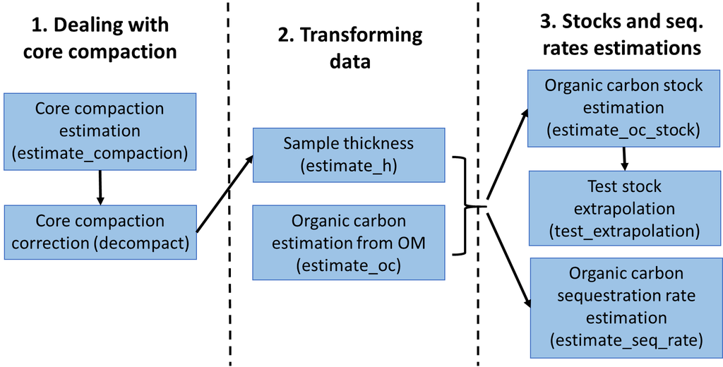

Blue Carbon library workflow

#### *estimate_compaction* **- Estimate Core Compaction**

Sampling soil cores by manual percussion usually leads to the compaction of the material retrieved. This function will estimate the percentage of compaction from measurements taken in the field after inserting the corer tube and before extracting it: length of the corer tube (sampler_length), distance between the surface of the soil and the top of the tube in the outside (external_distance) and distance between the surface of the soil and the top of the tube in the inside of the tube (internal_distance).

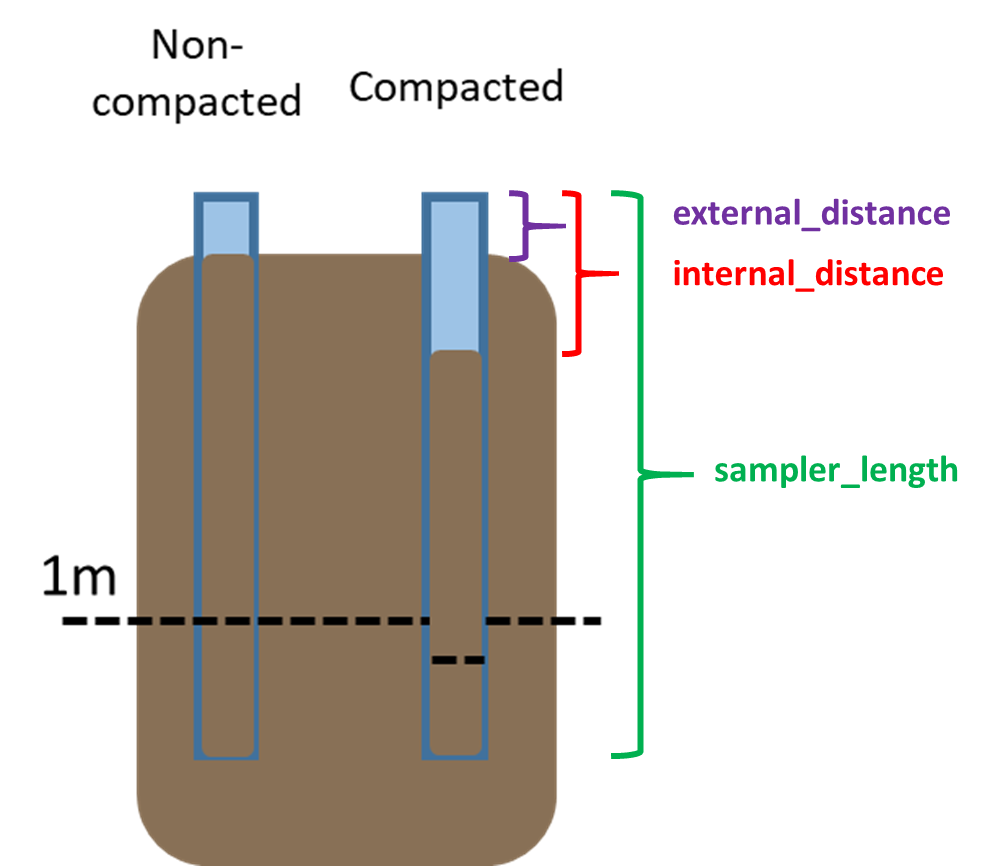

Soil compaction from field sampling

#### *decompact* **- Calculate sediment properties after decompaction**

Core compaction derived from field extraction can be mathematically correct to estimate the original depth of the samples. This function will apply a linear correction (all the core material is assumed to have been compacted equally) to correct sample depth and, if provided, dry bulk density.

#### *estimate_h* **- Sample thickness estimation**

For those cores were only selected samples were measured it is necessary to assign a carbon density to the empty spaces before the estimation the total stock. This function checks for gaps between samples and, if any, divide this space between the previous and next sample to return sample thickness without gaps in the core. The middle point between one sample and the other is estimated from the bottom of the previous sample to the top of the next sample, and not form the middle point of one sample to the middle part of the next, as this would inequality distribute the gaps between samples if the samples have different thickness. The stock and sequestration rate estimation functions (estimate_oc_stock and estimate_seq_rate) have this function incorporated and it is not necessary to run it beforehand.

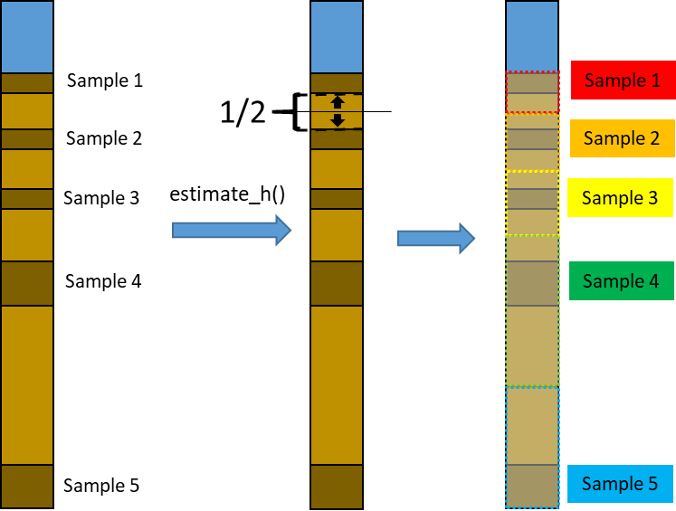

Gap distribution between samples to estimate accumulated organic carbon mass.

#### *estimate_oc_stock* **- Organic carbon stock estimation**

Estimates carbon stocks from soil core data down to a specified depth, 100 cm by default. If the core does not reach the desired depth, it extrapolates the stock from a linear model between accumulated mass of organic carbon and depth.

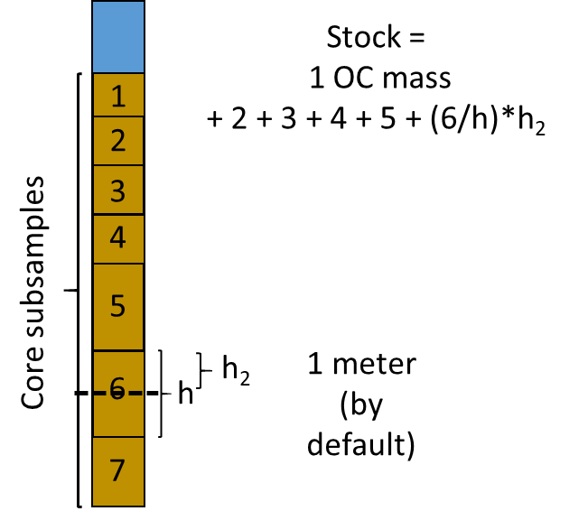

OC stock estimation diagram

#### *test_extrapolation* **- Visualize the error of stock extrapolation**

This function subset those cores that reach the desired depth, estimates the stock (observed stock), estimate the stock from the linear relation of organic carbon accumulated mass and depth using the 90, 75, 50 and 25% top length of the indicated desired depth. Compares the observed stock with the estimated stocks by extrapolation. This function requires that some of you core do reach the desired depth.

#### *estimate_seq_rate* **- Organic carbon sequestration rates estimation**

Estimate the average organic carbon sequestration rate to the soil in a indicated time frame (by default last 100 years) from the organic carbon concentration and the age of the samples.

# Availability

# Key References

Fourqureanet al. (2012) Seagrass ecosystems as a globally significant carbon stock. Nat. Geosci.5, 505–509. https://doi.org/10.1038/ngeo1477

Maxwell et al. (2023) Global dataset of soil organic carbon in tidal marshes.Sci.Data 10, 1–14.https://doi.org/10.1038/s41597-023-02633-x

Piñeiro-Juncal et al. (in prepp) Soil organic carbon preservation and decay trends in tidal marsh, mangrove and seagrass blue carbon ecosystems.

# Acknowledgements

The development of this software has been funded by Fondo Europeo de Desarrollo Regional (FEDER) and Consejería de Transformación Económica, Industria, Conocimiento y Universidades of Junta de Andalucía (proyecto US-1381388 led by Francisco Rodríguez Sánchez, Universidad de Sevilla). NPJ was supported by a Juan de la Cierva fellowship (JDC2022-048342-I, funded by MCIN/AEI/10.13039/501100011033 and the European Union “NextGenerationEU”/PRTR”). JA acknowledges funding from the CLIMB-FOREST Horizon Europe Project (No 101059888) that was funded by the European Union.

[figure not shown]